# team

Peter Cassioppi & Spencer Brown

9/26/2019

Owner’s GitHub: pcassioppi Partner’s GitHub: spencerqbrown Repo Name: ds202_lab3

We have a dataset of self-reported happiness levels along with some other bits of information about the self-reporters. We will do some simple cleaning on this ‘happy’ dataframe before we do an analysis. It seems as though there are several possible values that represent missing values. All missing values should be set to NA, including IAP, DK, and NA as a character type.

```r
happy <- readRDS("HAPPY.rds")
happy[happy=="IAP"]=NA
happy[happy=="DK"]=NA
happy[happy=="NA"]=NA
```

This way, we won’t have any issues with IAP and such being considered separate categories from NA, or not showing as NA when we need to be aware of missing values. Now, we’ll cast our variables to the proper data type like factor for categorical variables, a numerical type for numbers, etc.

```r
# first some simple ones, chars turned to factors
happy$HAPPY = as.factor(happy$HAPPY)
happy$SEX = as.factor(happy$SEX)
happy$MARITAL = as.factor(happy$MARITAL)
happy$DEGREE = as.factor(happy$DEGREE)
happy$FINRELA = as.factor(happy$FINRELA)
happy$HEALTH = as.factor(happy$HEALTH)
happy$PARTYID = as.factor(happy$PARTYID)
happy$POLVIEWS = as.factor(happy$POLVIEWS)
# now age needs to be set to numerical
happy$AGE[happy$AGE=="89 OR OLDER"]="89"
happy$AGE = as.integer(happy$AGE)
str(happy)
```

```
## 'data.frame':    62466 obs. of  11 variables:
##  $ HAPPY   : Factor w/ 3 levels "NOT TOO HAPPY",..: 1 1 2 1 2 2 1 1 2 2 ...
##  $ YEAR    : int  1972 1972 1972 1972 1972 1972 1972 1972 1972 1972 ...
##  $ AGE     : int  23 70 48 27 61 26 28 27 21 30 ...
##  $ SEX     : Factor w/ 2 levels "FEMALE","MALE": 1 2 1 1 1 2 2 2 1 1 ...
##  $ MARITAL : Factor w/ 5 levels "DIVORCED","MARRIED",..: 3 2 2 2 2 3 1 3 3 2 ...
##  $ DEGREE  : Factor w/ 5 levels "BACHELOR","GRADUATE",..: 1 5 3 1 3 3 3 1 3 3 ...
##  $ FINRELA : Factor w/ 5 levels "ABOVE AVERAGE",..: 2 1 2 2 1 1 1 2 2 3 ...
##  $ HEALTH  : Factor w/ 4 levels "EXCELLENT","FAIR",..: 3 2 1 3 3 3 1 3 1 2 ...
##  $ WTSSALL : num  0.445 0.889 0.889 0.889 0.889 ...
##  $ PARTYID : Factor w/ 8 levels "IND,NEAR DEM",..: 1 4 3 4 7 1 1 1 7 7 ...
##  $ POLVIEWS: Factor w/ 7 levels "CONSERVATIVE",..: NA NA NA NA NA NA NA NA NA NA ...
```

Now that all of our columns are of the desired type, we only have a bit more cleaning to do before exploring the data. We’ll just reorder some of the factor levels so they aren’t functionally random.

```r
# HAPPY is ordered reasonably, going from least to most happy, so it will stay the same
# SEX, MARITAL, PARTYID, are nominal, so we'll just arbitrarily order them using mean AGE
happy$SEX = reorder(happy$SEX, happy$AGE, mean)
happy$MARITAL = reorder(happy$MARITAL, happy$AGE, mean)
happy$PARTYID = reorder(happy$PARTYID, happy$AGE, mean)
# We'll reorder HEALTH so it goes from least to most healthy
library(forcats)
happy$HEALTH = fct_rev(happy$HEALTH)
# We'll order POLVIEWS from most conservative to most liberal, manually
happy$POLVIEWS = fct_relevel(happy$POLVIEWS, "EXTRMLY CONSERVATIVE", "CONSERVATIVE", "SLGHTLY CONSERVATIVE", "MODERATE", "SLIGHTLY LIBERAL", "LIBERAL", "EXTREMELY LIBERAL")
# Same sort of deal with DEGREE and FINRELA
happy$DEGREE = fct_relevel(happy$DEGREE, "LT HIGH SCHOOL", "HIGH SCHOOL", "JUNIOR COLLEGE", "BACHELOR", "GRADUATE")
happy$FINRELA = fct_relevel(happy$FINRELA, "FAR BELOW AVERAGE", "BELOW AVERAGE", "AVERAGE", "ABOVE AVERAGE", "FAR ABOVE AVERAGE")
```

Now that our data frame is in our desired format, we can move onto some exploratory data analysis. We’ll start with some simple distributions before moving onto how variables relate to each other.

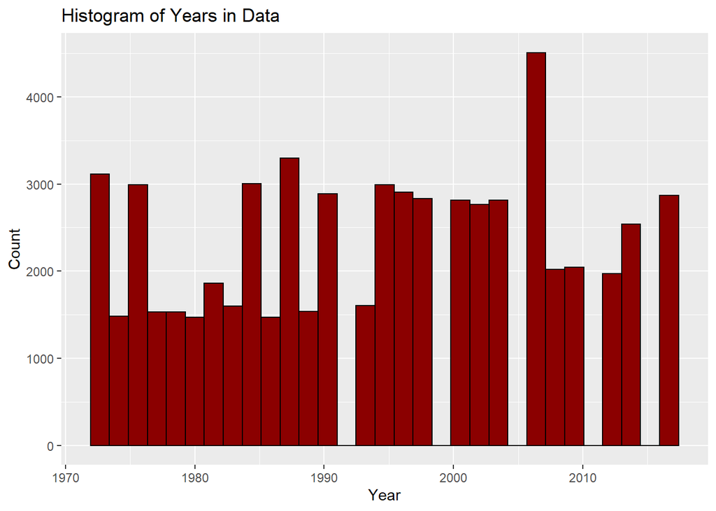

```r
library(ggplot2)
ggplot(happy, aes(YEAR))+geom_histogram(bins = length(unique(happy$YEAR)), color='Black', fill='Dark Red')+labs(title="Histogram of Years in Data",x = "Year",y = "Count")
```

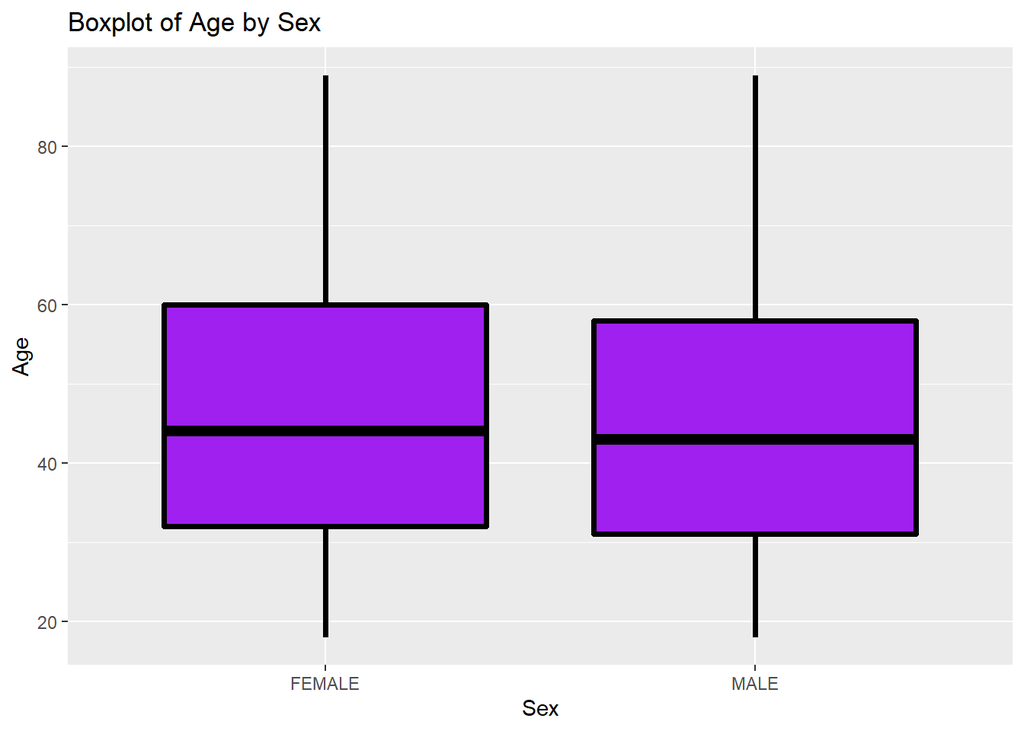

```r
ggplot(happy, aes(SEX, AGE))+geom_boxplot(color='Black', fill='Purple', size=1.25)+labs(title="Boxplot of Age by Sex",x = "Sex",y = "Age")
```

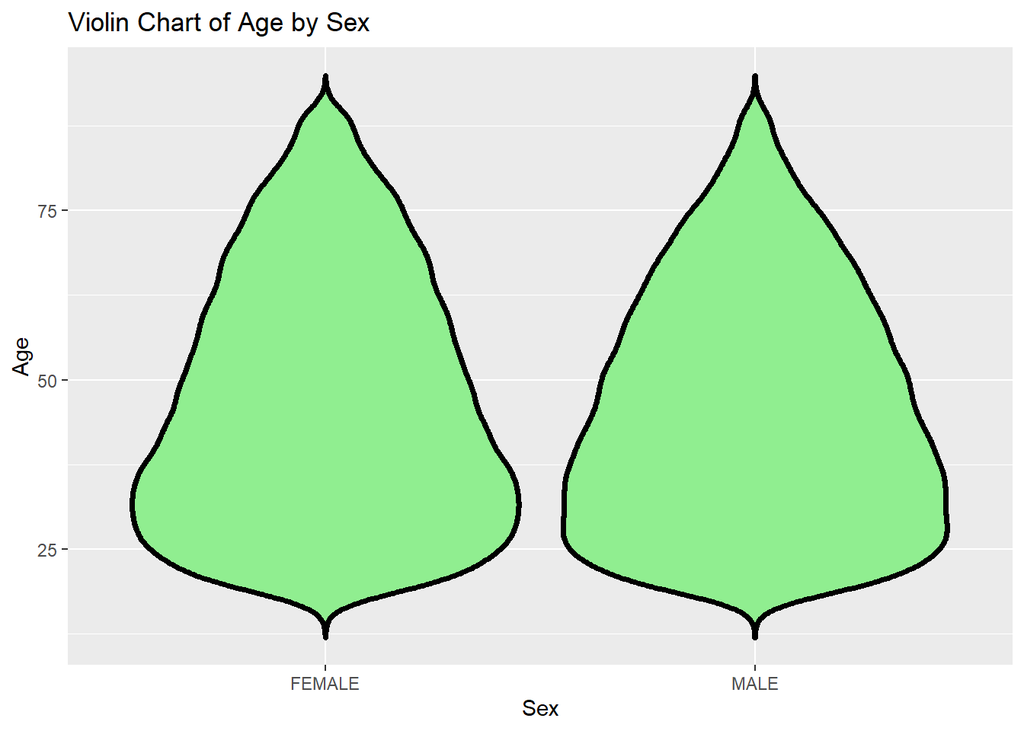

```r
ggplot(happy, aes(SEX, AGE))+geom_violin(color='Black', fill='Light Green', size=1.25, trim=FALSE)+labs(title="Violin Chart of Age by Sex",x = "Sex",y = "Age")
```

In order to find the distribution of ages for each sex, we made a boxplot and violin plot for both genders. From these plots we can see that the ages for the survey were pretty close in distribution for each sex. One thing we can see is that the male data seems to be younger than the female data, because the whole male box in the boxplot is lower than the box for females. The median of the age for men is slightly lower than the females who responded to the survey, and so are the first and third quartiles. But, overall we can say that the median age for both sexes seems to be around 44 or 45, and the interquartile range is about 31-60. The violin chart shows us that the survey was very heavily influnced by younger peope, as there is a large bottom section of the chart around age 30.

Now that we have a bit of info on how a few variables are distributed, we can see how they relate to each other.

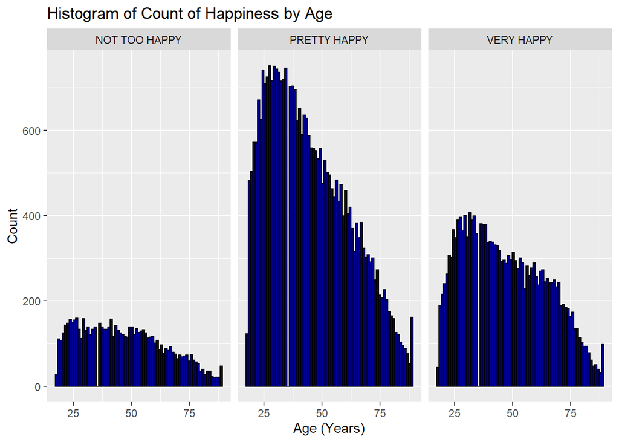

```r
#initially there was an NA facet for people who didn't respond to the question, here I remove those values
index = which(is.na(happy$HAPPY))
happy2 = happy[-index,]


ggplot(happy2, aes(AGE))+geom_histogram(bins = length(unique(happy2$AGE)), color='Black', fill='Dark Blue')+facet_wrap(~HAPPY)+labs(title="Histogram of Count of Happiness by Age",x = "Age (Years)",y = "Count")
```

In this histogram, we can right away see that most people responded to the question with the answer Pretty Happy. This may be because it is the choice in the middle of the three choices, which would make it a likely choice for a lot of people to pick. We do see a spike up at the end of the ages for each graph, but that is only because the maximum age available to enter in the survey was 89, so that is the cause of the spike. One thing of note we can learn from these graphs is that while all the charts are right skewed, the not too happy graph is less skewed than the others. This tells us that younger people were less likely to answer not too happy than the other graphs. There also seems to be a gap where one of the ages had no responses to the questions, somewhere around 35.

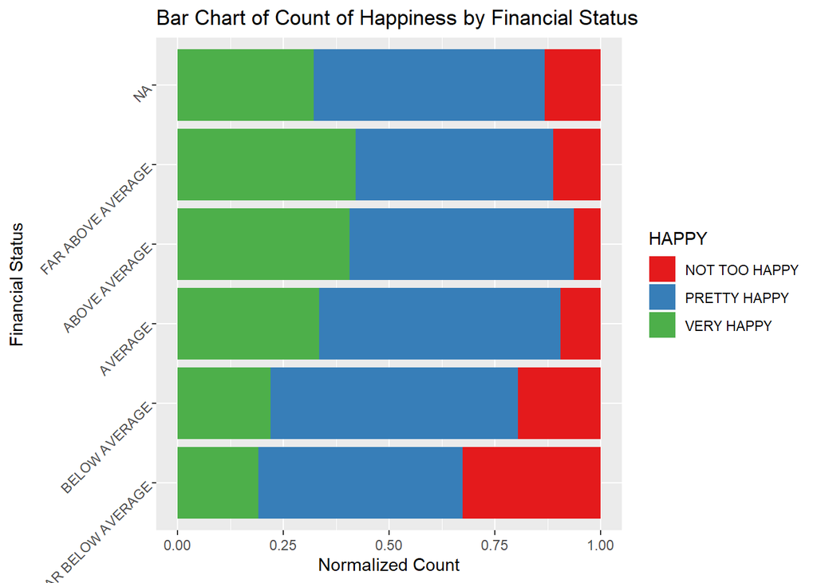

```r
ggplot(happy2, aes(FINRELA, fill=HAPPY))+geom_bar(position='fill')+labs(title="Bar Chart of Count of Happiness by Financial Status",x = "Financial Status",y = "Normalized Count")+ theme(axis.text.y = element_text(angle = 45))+coord_flip()+ scale_fill_brewer(palette="Set1")
```

In this bar chart, we can see that, of the people surveyed, there is a relationship between financial situation and happiness. The responders with a Far Above Average situation have about the first or second highest Very Happy responses, as it is very close with the Above Average situation. From this graph, we can also see that the Not Too Happy responses for the Below Average and Far Below Average responses are the two highest for any of the groups, This tells us that people who are better off financially (or say that they are) are more happy than people in a worse financial state. One other interesting thing this graph tells us, is that people who didn’t know, or didn’t want to disclose, their financial situation and responded NA seem less happy than the people whose situation is Average.

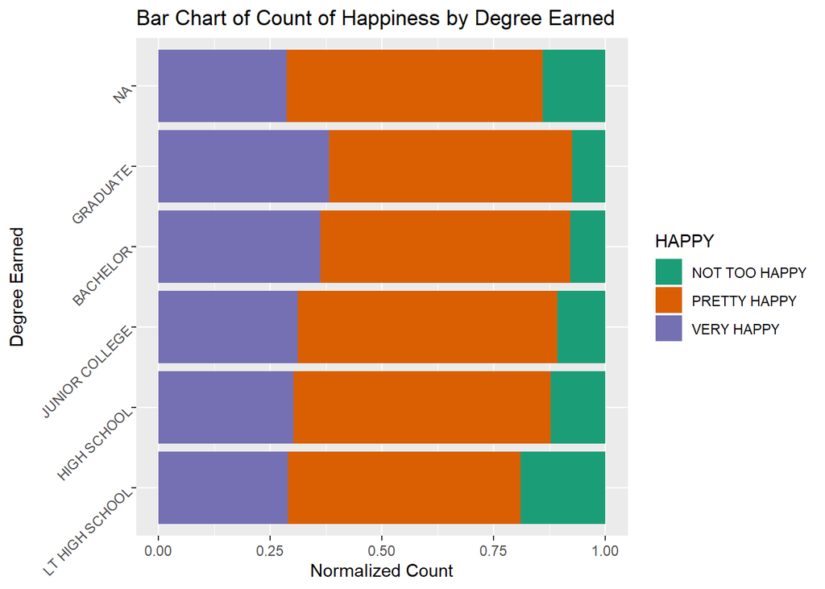

```r
ggplot(happy2, aes(DEGREE, fill=HAPPY))+geom_bar(position="fill")+theme(axis.text.y = element_text(angle = 45))+coord_flip()+ scale_fill_brewer(palette="Dark2")+labs(title="Bar Chart of Count of Happiness by Degree Earned",x = "Degree Earned",y = "Normalized Count")
```

From this barchart that is similar to the previous one, we can see that of the people that responded, the ones who went to college and graduate school are on average happier than the other groups. We can see that the less educated members of the survey seemed to be less happy, and each level of education seems to make them happier. We can say this because we can see a slight increase in the Very Happy column as we go from Left High School through Junior College, and a larger jump when we get to Bachlors Degrees and Graduate Degrees. These trends continue in the inverse on the Not Too Happy side of the graph, with less and less responders saying they are unhappy the more education they have.